# Tarea 4 Genómica Funcional 2025

## (80 % ) Scripts, código, texto y gráficas

1. **Propiedades básicas de redes**

A partir de las siguientes redes calcula manualmente las siguientes propiedades de cada red

- Número de conexiones
- Número de nodos
- Degree
- Average degree
- Degree distribution
- Density
- Adjacency matrix
- Matriz de distancia
- Diámetro
- Nodos más distantes
- Coeficiente de clusterización

Después escribe código en R que genere las gráficas de las redes y que calcule las propiedades anteriores para cada red.

*Ejercicios a mano se encuentran en la carpeta ejercicios dentro del pdf con el mismo nombre*

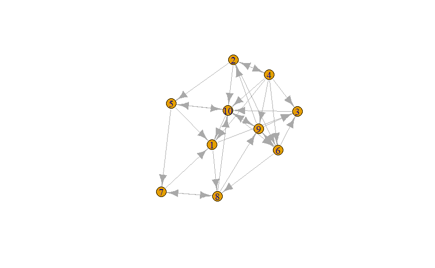

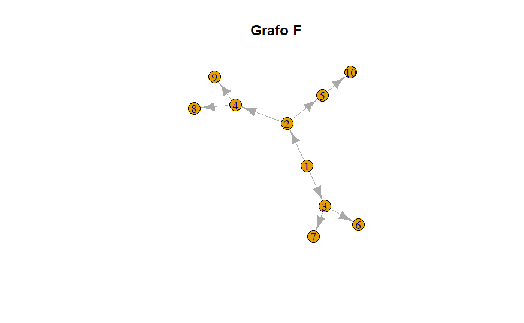

```r
#Propiedades
```

1. **Karate**

Considera la red del club de Karate de Zachary. [Acá](https://en.wikipedia.org/wiki/Zachary%27s_karate_club) puedes leer sobre eso. En igraph la gráfica está precargada

```r
library(igraph)

karate <- make_graph ("Zachary")
```

- ¿Cuántos nodos y conexiones tiene?

```r
karate
```

IGRAPH fcc9838 U— 34 78 – Zachary Indica una red U - undirected (no dirigida) de 34 nodos y 78 conexiones

- ¿Quiénes son los nodos y cuál es la regla de conexión?

Los nodos son los miembros del club de karate, y la regla de conexión son las interacciones sociales fuera entre los miembros

- ¿Qué tan densa es la red?

```r
edge_density (karate)
```

- ¿Cómo obtienes la matriz de adyacencia?

```r
adj_mat <- as.matrix (get.adjacency (karate) )
adj_mat
```

La matriz de adyacencia se obtiene asignando un nodo a cada miembro de la red. Según la interacción entre nodos se llena la matriz, el 1 indica una conexión, mientras que la ausencia de interacción se denota con un 0.

- ¿Es una red dirigida, pesada?

Es una red no dirigida, según lo indicado por su identificador `#IGRAPH fcc9838 U---` (U de uniderected)

- Calcula y gráfica la distribución de conectividades

```r
#Calculo de distribución de conectividades
degree(karate)
#Gráfica
dist_con <- hist(degree(karate), col="seagreen", main = "Distribución del grado")
dist_con
```

- Calcula el diámetro, la matriz de distancias y la distancia promedio

```r
# Diámetro
diameter (karate)
# Matriz de distancias
dist_mat <- distances (karate)
# Distancia promedio
mean_distance (karate)
```

- Encuentra la trayectoria de los nodos más alejados.

```r
sort( (get_diameter (karate)), decreasing = TRUE)
#Da la secuencia de nodos que forman el diámetro
```

- Existen nodos con coeficiente de clusterización 1. ¿Qué significa?

```r
transitivity (karate, type = "local")
```

Los nodos con coeficiente de cluesterización igual a 1 demustran que cada uno de los nodos a los que está conectado también están conectados entre sí.

- Mide , con al menos tres medidas de centralidad, los nodos más importantes.

```r
# visualización de la gráfica
plot(karate, main = "Gráfica karate") #para saber seleccionar los hubs

#Elijo sort para que calcule mayor a menor
head ( sort (degree(karate), decreasing = TRUE), 5)
head ( sort (betweenness(karate), decreasing = TRUE), 5)
head ( sort (closeness(karate), decreasing = TRUE), 5)
```

**Explica e interpreta tus resultados**.

2. **Amigues**

```r
#Cargar la red
g2 <- read.csv("R/Genómica Funcional/Tarea 4/Data/adjacency_matrix.csv")
```

A partir de la red de amigues que vimos en clase, en su versión no ponderada, contesta lo siguiente:

- Escribe una función que calcule el número de amigos que tiene cualquier persona arbitraria y lo compare con el número de los amigos de estos.

```r
#Comprobar la función
amigos_de_amigos("JULIETA")
```

```
Amigos de la persona: 7
Amigos de sus amigos: 7 3 6 9 5 3 16
```

- Escribe una función que te de la trayectoria más larga entre dos nodos arbitrarios de la red.

```r
trayectoria_larga <- function (persona1, persona2) {
  #Calcular los trayectos
  trayectos <- all_simple_paths (red, from = persona1, to =persona2, mode = "all" )
  #Añado all porque in y out no los calcula
  #Calcular la longitud de los paths
  long_trayectos <- sapply (trayectos, function (tray) length (tray) - 1 )
  #Añadí el -1 porque lo que da es el número de nodos, si se resta 1 da la conexión entre estos
  max_trayecto <- trayectos[[which.max(long_trayectos)]]
  #Trayectos guarda la secunia de nodos y long_trayectos la longitud
  max_long <- max(long_trayectos)

  cat("Máximo trayecto:", paste(max_trayecto, collapse = " -> "), "\n") #Colapse permite que se muestren en serie añadiendo la flecha -> hace más entendible el trayecto
  cat ("Longitud máxima:", max_long)

}


trayectoria_larga ("JULIETA", "BLANCA")
```

- Encuentra las dos personas más populares.

```r
#Acomodar en función de su popularidad, de mayor a menor
sort(popularidades, decreasing = TRUE)
```

```
 DANIELA     ZAID  ABRAHAM  MELISSA MICHELLE   XYMENA  ALONDRA     IVAN  JULIETA   BLANCA
       9        9        8        8        8        8        6        6        6        5
ESTRELLA   ISABEL   ANDRES   MIGUEL SANTIAGO TRINIDAD     LUIS    CARLA CRISTINA   NATALY
       5        5        4        4        4        4        3        2        2        2
  JIMENA
       0
```

3. **Red PPI**

A partir de la red de interacción proteína-proteína (PPI) de la levadura que se encuentra en la bilbioteca `igraphdata` Elabora un script que conteste lo siguiente:

```r
#Pide actualizar la base de datos
igraph::upgrade_graph(yeast)
```

```
IGRAPH 65c41bb UN-- 2617 11855 -- Yeast protein interactions, von Mering et al.
+ attr: name (g/c), Citation (g/c), Author (g/c), URL (g/c), Classes (g/x), name
| (v/c), Class (v/c), Description (v/c), Confidence (e/c)
+ edges from 65c41bb (vertex names):
 [1] YLR197W--YDL014W YOR039W--YOR061W YDR473C--YPR178W YOR332W--YLR447C YER090W--YKL211C
 [6] YDR394W--YGR232W YER021W--YPR108W YPR029C--YKL135C YIL106W--YGR092W YKL166C--YIL033C
[11] YGL026C--YKL211C YOR061W--YGL019W YGL115W--YER027C YGL049C--YGR162W YDR394W--YOR117W
[16] YDL140C--YML010W YLR291C--YKR026C YGR158C--YDL111C YDR328C--YDL132W YOL094C--YNL290W
[21] YDR460W--YPR025C YBR154C--YOR341W YBR154C--YOR116C YIL062C--YKL013C YBR154C--YOR207C
[26] YBR154C--YPR010C YER027C--YDR477W YLR291C--YGR083C YPL093W--YDR496C YER006W--YMR049C
[31] YER006W--YMR290C YFR052W--YHR200W YOR261C--YFR004W YHR052W--YDR496C YDL140C--YBR154C
+ ... omitted several edges
```

- Encuentre qué tipo de distribución de conectividades tiene. Haz un ajuste en log-log para ver que tipo de distribución podría ser.
- Encuentra las diez proteínas más conectadas

```r
density(yeast)
```

[output not shown]

- Calcula el diámetro y promedio de las distancias

```r
mean_distance (yeast)
```

```
[1] 5.095629
```

- Crea una función que, a partir de eliminar al azar un nodo de la red genere el promedio d elas distancias después de eliminar $n=1,2,3,\ldots, 100$ nodos al azar

```r
delecion_sucesiva (y2, 400)
```

```
Distancia promedio inicial: 5.095629
Distancia promedio final: 5.297123
```

- Crea una función que elimine las proteínas más conectadas y calcule el promedio de las distancias cada vez que se remueve un nodo.

```r
delecion_conect(y3, 400)
```

```
Distancia promedio inicial: 5.095629
Distancia promedio final: 5.550046
```

- Calcula el promedio del coeficiente de clusterización. ¿Hay proteínas que tengan un coeficiente de clusterización de 1? Eso qué significa.

```r
any (prot_cc == 1) #Sí hay proteínas con CC = 1
```

```
[1] TRUE
```

Con un total de 2617 nodos y 11855 conexiones, yeast se trata de una base de datos bastante compleja, característico de las interacciones proteína-proteína (PPI). Por esto, al aplicar las funciones de deleción, se optó por seleccionar un número alto (400) para las iteraciones, borrando nodos tanto con más conexiones y los nodos seleccionados al azar. De estos resultados se ve que la distancia promedio aumenta más al utilizar la función `delecion_conect`, pues esta función elige a los hubs, que son nodos altamente conectados, por lo que al borrarlos, es más probable que la red se fragmente, aumentando así la distancias promedios debido a la pérdida de conexiones. Por otro lado, la función `delecion_sucesiva` elige qué nodos eliminar aleatoriamente, por lo que hay una probabilidad más baja de seleccionar nodos clave (hubs) cuando estos son eliminados, resultando en un menor impacto en la distancia promedio.

4. **Redes biológicas**

Ve a al [Network Repository](https://networkrepository.com/bn-mouse-visual-cortex-1.php) y descarga la red en formato lista de adyacencia. Explica que representam los nodos y las conectividades.

Escribe código que resuelva lo siguiente: - Cargue y genere una gráfica en `igraph`.

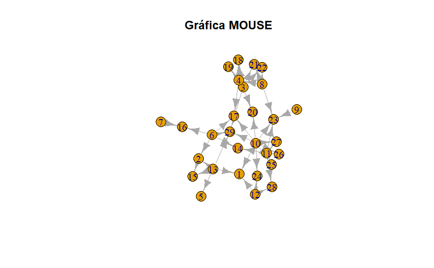

- Genera la gráfica con todos los layouts disponibles.

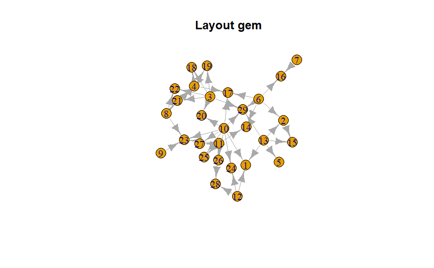

- Grafica la red con al menos tres medidas de centralidad.
- ¿Qué tan densa es la red?

```r
edge_density(mouse)
```

```
[1] 0.05418719
```

- Clusteriza la red con al menos tres métodos de clusterización. Gráfica la red con esos métodos.

Explica tus resultados.

5. **Red de coexpresión simulada**

Simula una matriz de expresión con 20 genes en 6 condiciones diferentes.

- Calcula la correlación entre todos los pares de genes.
- Construye una red de coexpresión utilizando un umbral de correlación > 0.8.
- Calcula la distribución de grados.
- Identifica si hay módulos o agrupamientos de genes altamente correlacionados.
- Visualiza la red y discute qué tipo de topología tiene.
6. **Comparación de redes**

Construye dos redes:

- Una red aleatoria tipo Erdos-Rényi.
- Una red tipo “scale-free” usando el modelo Barabási–Albert.

Para ambas redes:

- Compara su grado promedio, distribución de grados, coeficiente de clusterización y diámetro.

```r
comparacion(g_ba)
```

```
Grado promedio: 1.98
Distribución de grados: 0 0.59 0.23 0.08 0.02 0.01 0.02 0.02 0.01 0 0.01 0 0.01
CC promedio: 0
Diámetro: 13
```